# Practical Machine Learning Course Project

Rony Morales

8/1/2020

##Introduction: Using devices such as Jawbone Up, Nike FuelBand, and Fitbit it is now possible to collect a large amount of data about personal activity relatively inexpensively. These type of devices are part of the quantified self movement - a group of enthusiasts who take measurements about themselves regularly to improve their health, to find patterns in their behavior, or because they are tech geeks. One thing that people regularly do is quantify how much of a particular activity they do, but they rarely quantify how well they do it.

In this project, we will use data from accelerometers on the belt, forearm, arm, and dumbell of 6 participants. They were asked to perform barbell lifts correctly and incorrectly in 5 different ways.

The data consists of a Training data and a Test data (to be used to validate the selected model).

The goal of your project is to predict the manner in which they did the exercise. This is the “classe” variable in the training set. You may use any of the other variables to predict with. A: Exactly according to the specification B: Throwing the elbows to the front C: Lifting the dumbell only halfway D: Lowering the dumbell only halfway E: Throwing the hips to the front

```r
library(knitr)
library(caret)
library(corrplot)
library(rpart)
library(rpart.plot)
library(rattle)
library(randomForest)
library(e1071)
```

Data downloading and Processing

```r
trainURL<-"https://d396qusza40orc.cloudfront.net/predmachlearn/pml-training.csv"

testURL<-"https://d396qusza40orc.cloudfront.net/predmachlearn/pml-testing.csv"
```

Reading data

```r
training<-read.csv(trainURL)

testing<-read.csv(testURL)

# Data Analysis

dim(training)
```

```
## [1] 19622   160
```

```r
dim(testing)
```

```
## [1]  20 160
```

Data Slicing

```r
inTrain<-createDataPartition(training$classe, p=0.7, list=FALSE)

trainSet<-training[inTrain,]

testSet<-training[-inTrain,]

dim(trainSet)
```

```
## [1] 13737   160
```

```r
dim(testSet)
```

```
## [1] 5885  160
```

Cleaning even further by removing the variables that are near-zero-variance

```r
## In data cleaning, first, remove the NA values from the data set

trainSet1<-trainSet[ , colSums(is.na(trainSet))==0]
testSet1<-testSet[ , colSums(is.na(testSet))==0]
dim(trainSet1)
```

```
## [1] 13737    93
```

```r
dim(testSet1)
```

```
## [1] 5885   93
```

```r
nearZero<-nearZeroVar(trainSet1)
trainSet2<-trainSet1[ , -nearZero]
testSet2<-testSet1[ , -nearZero]
dim(trainSet2)
```

```
## [1] 13737    59
```

```r
dim(testSet2)
```

```
## [1] 5885   59
```

```r
trainSet3<- trainSet2[ , -c(1:7)]
testSet3<-testSet2[ , -c(1:7)]
dim(trainSet3)
```

```
## [1] 13737    52
```

```r
dim(testSet3)
```

```
## [1] 5885   52
```

Correlation analysis

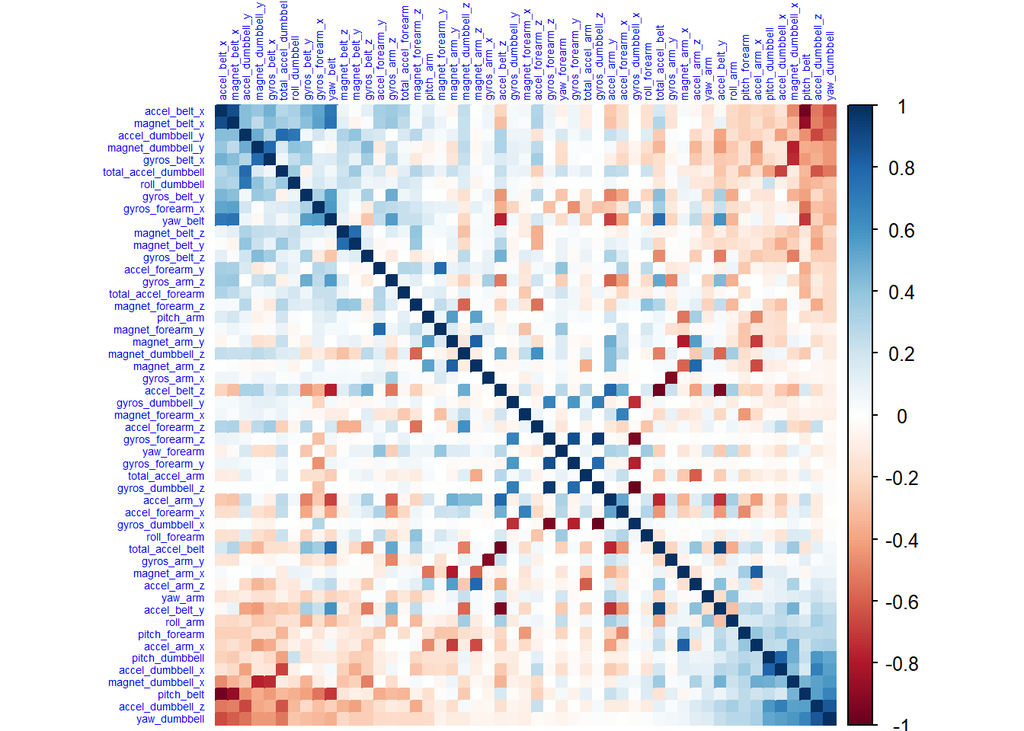

```r
trainD<-sapply(trainSet3, is.numeric)
corMatrix<-cor(trainSet3[trainD])
corrplot(corMatrix, order="FPC", method="color",
           tl.cex=0.45, tl.col="blue", number.cex=0.25)
```

```r
highCor<-findCorrelation(corMatrix, cutoff=0.75)
names(trainSet3)[highCor]
```

```
##  [1] "accel_belt_z"      "accel_dumbbell_z"  "accel_belt_y"
##  [4] "accel_arm_y"       "yaw_belt"          "accel_belt_x"
##  [7] "pitch_belt"        "magnet_dumbbell_x" "accel_dumbbell_y"
## [10] "magnet_dumbbell_y" "accel_arm_x"       "accel_dumbbell_x"
## [13] "accel_arm_z"       "magnet_arm_y"      "magnet_belt_z"
## [16] "accel_forearm_y"   "gyros_forearm_y"   "gyros_dumbbell_x"
## [19] "gyros_dumbbell_z"  "gyros_arm_x"
```

Prediction model building For this project it will be applied two models to predict the outcome variable. 1. Decision tree model 2. Random Forest model

Method1: Decision trees

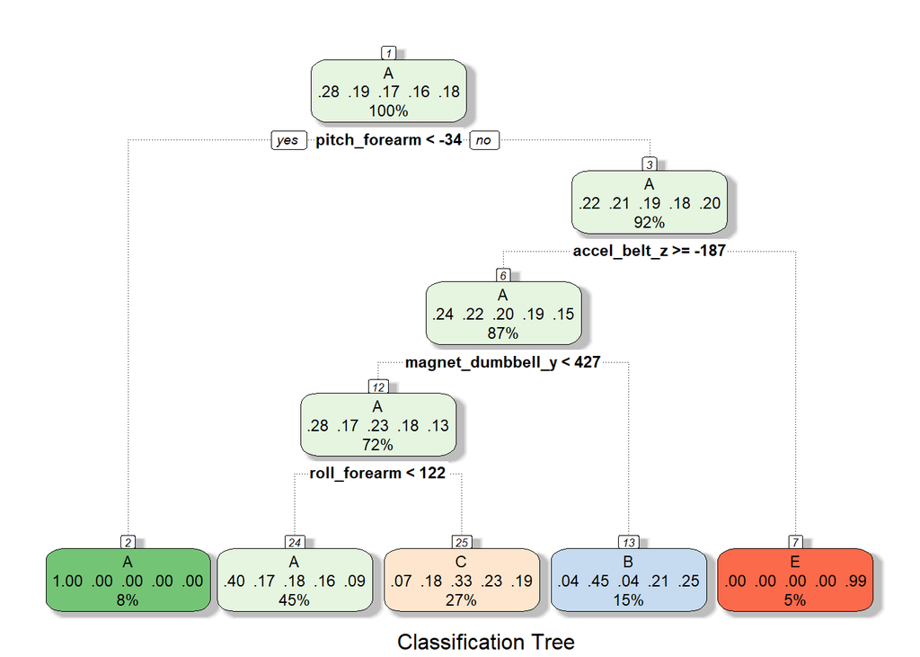

```r
## Model fit
DTcontrol<-trainControl(method="cv", number=5)
DTmodel<-train(classe~., data=trainSet3,
               method=  "rpart", trControl=DTcontrol)
fancyRpartPlot(DTmodel$finalModel,
               sub="Classification Tree")
```

Prediction on test data set

```r
DTpred<-predict(DTmodel, newdata=testSet3)
DTcfm<-confusionMatrix(table(DTpred,testSet3$classe))

DTcfm
```

```
## Confusion Matrix and Statistics
##
##
## DTpred    A    B    C    D    E
##      A 1497  432  448  415  225
##      B   38  417   44  187  250
##      C  136  290  534  362  294
##      D    0    0    0    0    0
##      E    3    0    0    0  313
##
## Overall Statistics
##
##                Accuracy : 0.4692
##                  95% CI : (0.4563, 0.482)
##     No Information Rate : 0.2845
##     P-Value [Acc > NIR] : < 2.2e-16
##
##                   Kappa : 0.3067
##
##  Mcnemar's Test P-Value : NA
##
## Statistics by Class:
##
##                      Class: A Class: B Class: C Class: D Class: E
## Sensitivity            0.8943  0.36611  0.52047   0.0000  0.28928
## Specificity            0.6390  0.89064  0.77732   1.0000  0.99938
## Pos Pred Value         0.4962  0.44551  0.33045      NaN  0.99051
## Neg Pred Value         0.9383  0.85411  0.88475   0.8362  0.86191
## Prevalence             0.2845  0.19354  0.17434   0.1638  0.18386
## Detection Rate         0.2544  0.07086  0.09074   0.0000  0.05319
## Detection Prevalence   0.5127  0.15905  0.27460   0.0000  0.05370
## Balanced Accuracy      0.7667  0.62838  0.64889   0.5000  0.64433
```

plot matrix results

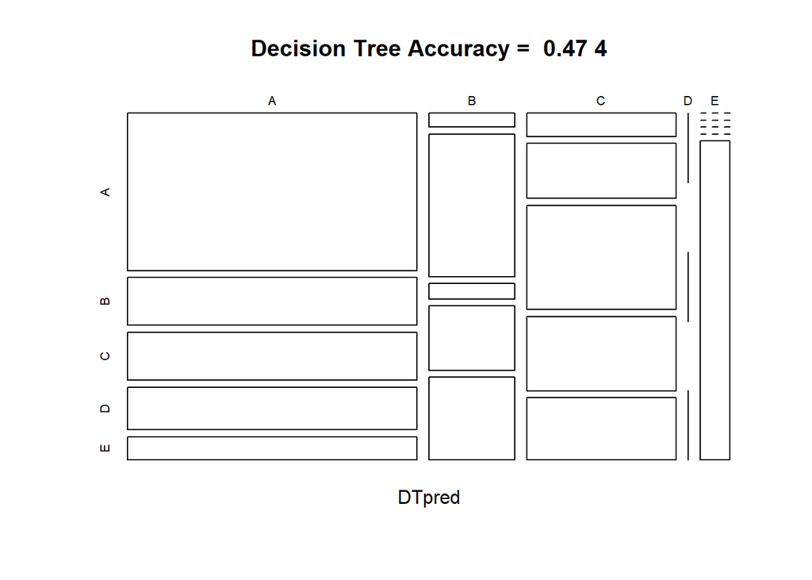

```r
plot(DTcfm$table, col=DTcfm$byClass,
      main=paste("Decision Tree Accuracy = ",   round(DTcfm$overall['Accuracy'], digits=2),4))
```

In Decision tree model’s accuracy, there is a significant expected ‘out of sample error’. Method2: Random Forest

```r
## Model fit

RFmodel<-randomForest(as.factor(classe)~.,
        data=trainSet3, ntree=500, importance=TRUE)
RFmodel
```

```
##
## Call:
##  randomForest(formula = as.factor(classe) ~ ., data = trainSet3,      ntree = 500, importance = TRUE)
##                Type of random forest: classification
##                      Number of trees: 500
## No. of variables tried at each split: 7
##
##         OOB estimate of  error rate: 0.51%
## Confusion matrix:
##      A    B    C    D    E  class.error
## A 3905    0    0    0    1 0.0002560164
## B    9 2641    8    0    0 0.0063957863
## C    0   17 2377    2    0 0.0079298831
## D    0    0   26 2224    2 0.0124333925
## E    0    0    1    4 2520 0.0019801980
```

Prediction on test data set

```r
RFpred<-predict(RFmodel, newdata=testSet3)

RFcfm<-confusionMatrix(table(RFpred, testSet3$classe))

RFcfm
```

```
## Confusion Matrix and Statistics
##
##
## RFpred    A    B    C    D    E
##      A 1672    4    0    0    0
##      B    1 1131    3    0    0
##      C    1    4 1022    7    0
##      D    0    0    1  956    1
##      E    0    0    0    1 1081
##
## Overall Statistics
##
##                Accuracy : 0.9961
##                  95% CI : (0.9941, 0.9975)
##     No Information Rate : 0.2845
##     P-Value [Acc > NIR] : < 2.2e-16
##
##                   Kappa : 0.9951
##
##  Mcnemar's Test P-Value : NA
##
## Statistics by Class:
##
##                      Class: A Class: B Class: C Class: D Class: E
## Sensitivity            0.9988   0.9930   0.9961   0.9917   0.9991
## Specificity            0.9991   0.9992   0.9975   0.9996   0.9998
## Pos Pred Value         0.9976   0.9965   0.9884   0.9979   0.9991
## Neg Pred Value         0.9995   0.9983   0.9992   0.9984   0.9998
## Prevalence             0.2845   0.1935   0.1743   0.1638   0.1839
## Detection Rate         0.2841   0.1922   0.1737   0.1624   0.1837
## Detection Prevalence   0.2848   0.1929   0.1757   0.1628   0.1839
## Balanced Accuracy      0.9989   0.9961   0.9968   0.9956   0.9994
```

plot matrix results

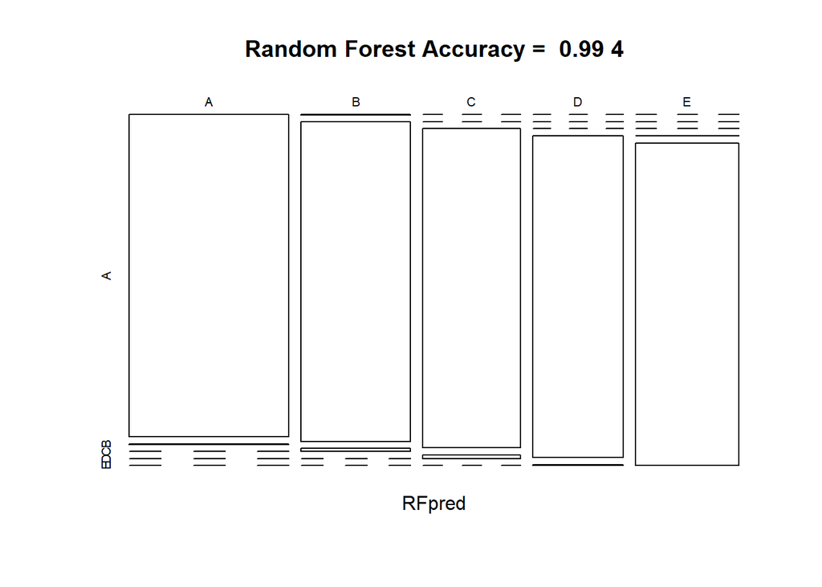

```r
plot(RFcfm$table, col=RFcfm$byClass,
      main=paste("Random Forest Accuracy = ", round(RFcfm$overall['Accuracy'], digits=2),4))
```

```r
finalPredict<-predict(RFmodel, newdata=testing)

finalPredict
```

```
##  1  2  3  4  5  6  7  8  9 10 11 12 13 14 15 16 17 18 19 20
##  B  A  B  A  A  E  D  B  A  A  B  C  B  A  E  E  A  B  B  B
## Levels: A B C D E
```

The Results output will be implemented to “Course Project Prediction Quiz”